Maurine Fort - Master 1 MIASHS BDA

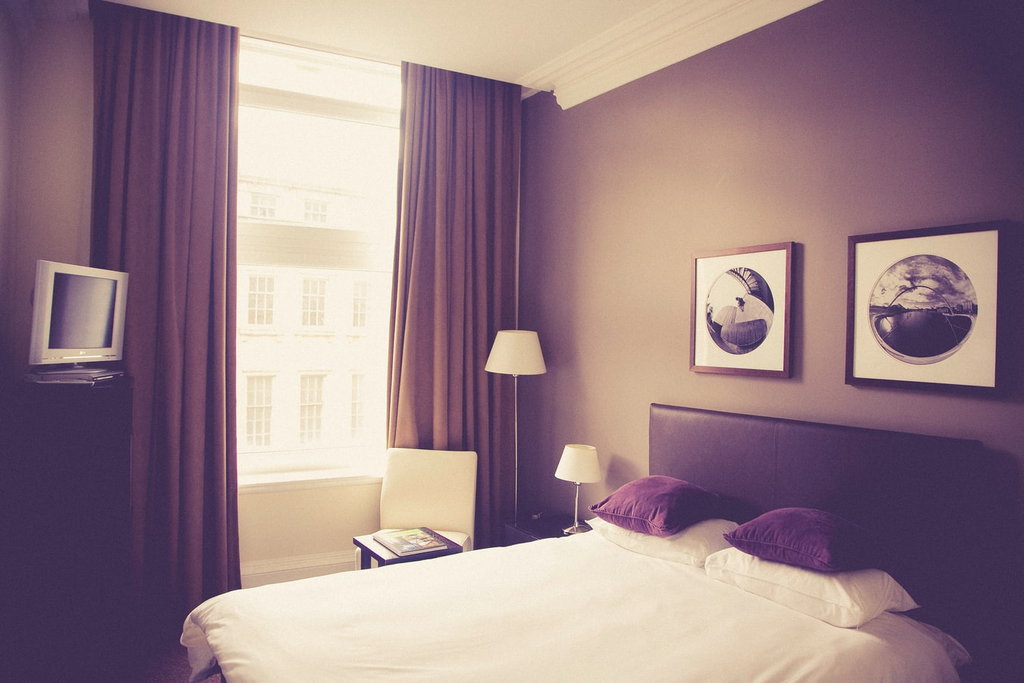

> Introduction

> **Présentation des données**

> La base de données ‘Hotel’ permet d’observer toutes les réservations effectuées afin de développer des modèles de prédiction pour classifier la probabilité d’annulation d’une réservation d’hôtel. Notre base de données rassemble deux sous bases. D’une part nous avons l’hôtel H1 qui est un hôtel de villégiature et d’un autre côté nous avons un hôtel de ville, H2. Les deux ensembles de données partagent la même structure, soit 31 variables décrivant les 40 060 observations de H1 et 79 330 observations de H2. Chaque observation représente une réservation d’hôtel. Les deux ensembles de données comprennent les réservations qui doivent arriver entre le 1er juillet 2015 et le 31 août 2017.
> - **hotel** : Type d’hôtel
> - **is_canceled** : Séjour annulé ou pas
> - **lead_time** : Délai de mise en oeuvre
> - **arrival_date_year** : Année d’arrivé
> - **arrival_date_month** : Mois d’arrivé
> - **arrival_date_week_number** : Semaine d’arrivé
> - **arrival_date_day_of_month** : Jour d’arrivé
> - **stays_in_weekend_nights** : Nombre de nuits le week-end
> - **stays_in_week_nights** : Nombre de nuits en semaine
> - **adults** : Nombre d’adultes
> - **children** : Nombre d’enfants
> - **babies** : Nombre de bébés
> - **meal** : Repas réservé
> - **country** : Pays d’origine
> - **market_segment** : Segment de marché
> - **distribution_channel** : Canal de distribution
> - **is_repeated_guest** : Nouveaux clients ou pas
> - **previous_cancellations** : Précédentes réservations annulées
> - **previous_bookings_not_canceled** : Précédentes réservations non annulées
> - **reserved_room_type** : Chambre réservé
> - **assigned_room_type** : Chambre assigné
> - **booking_changes** : Nombre de changements
> - **deposit_type** : Acompte déposé
> - **agent** : ID de l’agence
> - **company** : ID de l’entreprise
> - **days_in_waiting_list** : Nombre de jours en liste d’attente
> - **customer_type** : Type de clients
> - **adr** : Tarif journalier moyen
> - **required_car_parking_spaces** : Nombre de places de parking demandées
> - **total_of_special_requests** : Nombre de demandes spécialss formulées
> - **reservation_status** : Dernier statut de réservation
> - **reservations_status_date** : Date à laquelle le dernier statut a été défini

> **Chargement et nettoyage des données**

> Après avoir importé notre base de données, nous pouvons constater que la variable donnant le mois de la réservation est en caractère et non en date. Nous créeons donc une nouvelle variable date qui concatène les variables donnant le mois et l’année de réservation, en pensant bien à changer le type de la variable.

> **Les clients**

##### **1. Le nombre de nouveaux clients augmente-t-il durant la période étudiée ?**

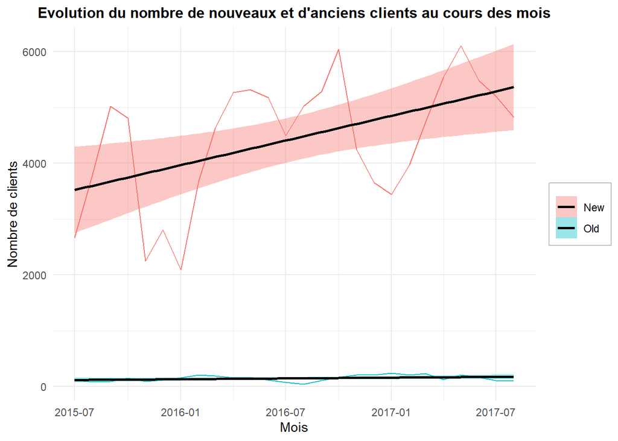

```r
hotels %>%
  select(is_repeated_guest, date) %>%
  group_by(date, is_repeated_guest) %>%
  summarise(N = n()) %>%
  drop_na() %>%
  ggplot(aes(x = date, y = N, fill = is_repeated_guest, color = is_repeated_guest)) +
  geom_line(show.legend = FALSE) +
  geom_smooth(aes(group = is_repeated_guest), method = lm, colour = "black") +
  labs(x = "Mois", y = "Nombre de clients", title = "Evolution du nombre de nouveaux et d'anciens clients au cours des mois" ) +
  theme_minimal() +
  theme(legend.title = element_blank(), plot.title = element_text(size = 12, face = "bold", hjust = 0.5),
        strip.background = element_rect(colour = "black", fill = "white", size = 1.5, linetype = "solid"),
        legend.background = element_rect(fill = "white", size = 0.5, linetype  ="solid", colour = "grey"),
        axis.title.x = element_text(size = 11),
        axis.title.y = element_text(size = 11))
```

Nous remarquons une augmentation de la part de nouveaux clients au cours des mois entre 2015 et 2017. Concernant les clients ayant déjà réservé dans ces hôtels, nous ne remarquons pas d’augmentation de leur part.

##### **2. D’où viennent la majorité des clients de ces hôtels ?**

```r
hotels %>%
  select(country) %>%
  group_by(country) %>%
  summarise(N = n()) %>%
  arrange(-N) %>%
  top_n(5) %>%
  kbl(col.names = c('Pays origine', 'Nombre')) %>%
  kable_styling(bootstrap_options = c("hover", "condensed"))
```

| Pays origine | Nombre |
| --- | --- |
| PRT | 48590 |
| GBR | 12129 |
| FRA | 10415 |
| ESP | 8568 |
| DEU | 7287 |

La plus grande majorité des clients de ces hôtels proviennent du Portugal. Cependant, une part importante de ces clients viennent également de l’Angleterre, de la France, de l’Espagne ou encore de l’Allemagne.

##### **3. Quelles sont les types de réservation préférés des clients ?**

```r
hotels$distribution_channel <- factor(hotels$distribution_channel, labels = c("TA/TO", "Direct", "Corporate", "GDS", "Undifined"))
df3 <- prop.table(table(hotels$distribution_channel))*100

dfgraph2 <- data.frame(df3)
colnames(dfgraph2) <- c("TypeReservation", "Pourcentage")

dfgraph2 %>%
  drop_na() %>%
  kbl(col.names = c('Type de reservation', 'Pourcentage'), digits = 3) %>%
  kable_styling(bootstrap_options = c("hover", "condensed")) %>%
  row_spec(row = 2, color = 'red') %>%
  row_spec(row = 4,color = 'red')
```

| Type de reservation | Pourcentage |
| --- | --- |
| TA/TO | 5.593 |
| Direct | 12.267 |
| Corporate | 0.162 |
| GDS | 81.975 |
| Undifined | 0.004 |

> **Mode de vie**

##### **4. Quel est le nombre de jours moyen écoulé entre la date de réservation et la date d’arrivée ?**

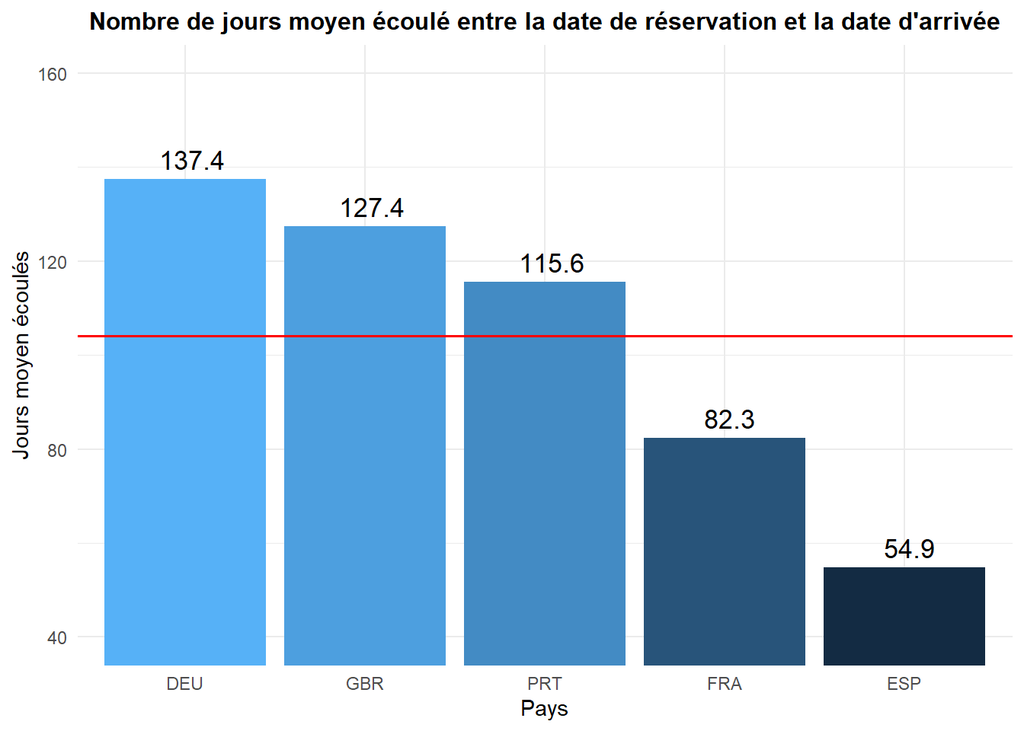

```r
hotels %>%
  select(country, lead_time) %>%
  filter(lead_time != "NA") %>%
  group_by(country) %>%
  summarise(mean_lead_time = mean(lead_time), na.rm = TRUE, N = n()) %>%
  arrange(-mean_lead_time, -N) %>%
  top_n(5) %>%
  ggplot(aes(x = reorder(country, -mean_lead_time), y = mean_lead_time, fill = mean_lead_time)) +
  geom_col(show.legend = FALSE) +
  geom_hline(yintercept = 104.0114,
                color = "red", size = 0.7) +
  geom_text(aes(label = round(mean_lead_time ,1), vjust = -0.5, hjust= 0.4), show.legend = FALSE, size = 4.6) +
  coord_cartesian(ylim = c(40,160)) +
  labs(x = "Pays", y = "Jours moyen écoulés", title = "Nombre de jours moyen écoulé entre la date de réservation et la date d'arrivée") +
  theme_minimal() +
  theme(plot.title = element_text(size = 12, face = "bold", hjust = 0.5  ),
        axis.title.x = element_text(size = 11),
        axis.title.y = element_text(size = 11))
```

Les allemands, les anglais ainsi que les portuguais sont des clients qui réservent leur séjour longtemps à l’avance, entre 115 et 137 jours. A l’inverse, les clients ayant comme pays d’origine le France et l’Espagne prévoient leur séjour moins longtemps à l’avance. Environ 2 mois et demi pour les français et moins de 2 mois pour les espagnols. De plus, la moyenne de jours écoulés entre la date de réservation et la date de séjour, tous pays compris est de 104 jours.

##### **5. Les mois les plus réservés sont-ils les mêmes selon le type d’hôtel ?**

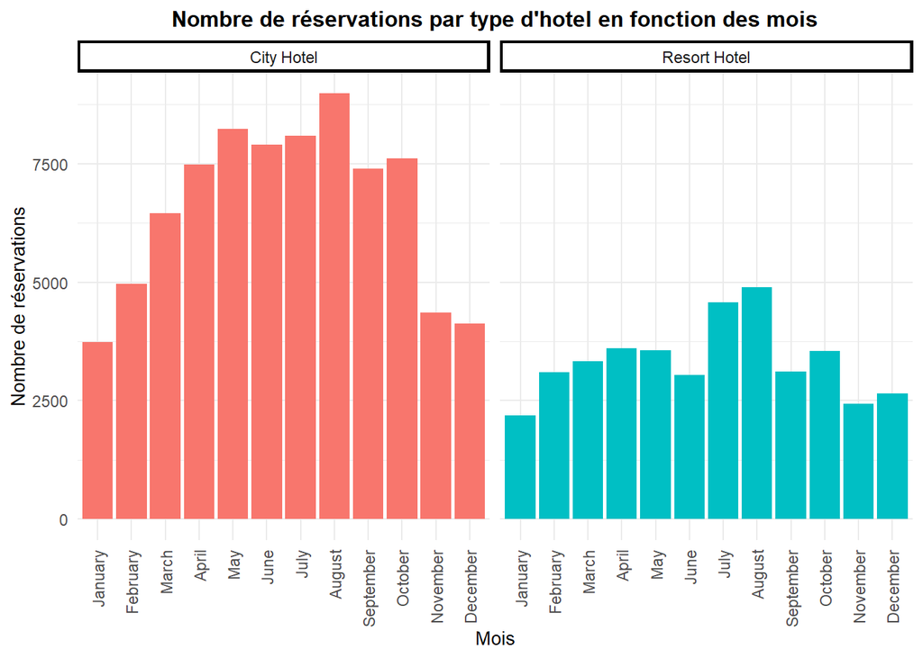

```r
hotels %>%
  select(hotel, arrival_date_month) %>%
  group_by(arrival_date_month, hotel) %>%
  summarise(N = n()) %>%
  ggplot(aes(x = factor(arrival_date_month, levels = month.name), y = N, fill = hotel)) +
  geom_col(show.legend = FALSE) +
  facet_wrap(~hotel) +
  labs(x = "Mois", y = "Nombre de réservations", title = "Nombre de réservations par type d'hotel en fonction des mois" ) +
  theme_minimal() +
  theme(legend.title = element_blank(), plot.title=element_text(size = 12, face = "bold", hjust = 0.5),
        strip.background = element_rect(colour = "black", fill = "white", size = 1.5, linetype = "solid"),
        axis.title.x = element_text(size = 10),
        axis.title.y = element_text(size = 10),
        axis.text.x = element_text(angle = 90, vjust = 0.5, hjust=1))
```

Les deux graphiques ci-dessus présentent la même tendance. En effet, que ce soit dans le City Hotel ou dans le Resort Hotel, les clients réservent plutôt des séjours durant le printemps ou l’été, soit, les saisons estivales. De plus, le mois d’août est le mois le plus réservé par les clients dans les deux types d’hôtels.

##### **6. Le fait d’avoir déjà annulé un séjour influence-t-il le fait d’annuler d’autres futurs séjours ?**

```r
cor.test(hotels$previous_cancellations, hotels$is_canceled, use = "complete.obs")
```

```
##
##  Pearson's product-moment correlation
##
## data:  hotels$previous_cancellations and hotels$is_canceled
## t = 38.287, df = 119388, p-value < 2.2e-16
## alternative hypothesis: true correlation is not equal to 0
## 95 percent confidence interval:
##  0.1045257 0.1157329
## sample estimates:
##       cor
## 0.1101328
```

Nous souhaitons savoir si le fait d’avoir déjà annulé un séjour influence le fait d’annuler de futurs séjours. Nous trouvons une corrélation égale à 0.11 ce qui signifie que les variables testées sont faiblement corrélées. Nous pouvons valider cette hypothèse grâce à la p-valeur. Celle ci est inférieure au seuil de significativité ce qui signifie que la corrélation entre les deux variables est significative.

##### **7. La part d’annulation des réservations suit-elle la même tendance dans les Resort Hotel que dans les City Hotel ?**

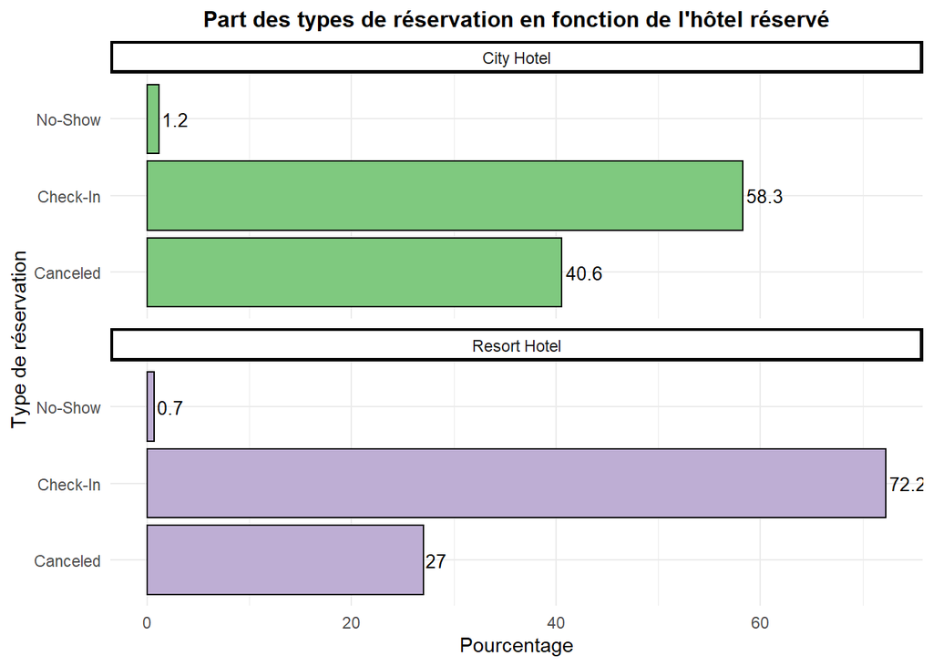

```r
hotels$reservation_status <- factor(hotels$reservation_status, labels = c("Canceled", "Check-In", "No-Show"))
df <- prop.table(table(hotels$reservation_status, hotels$hotel),2)*100

dfgraph <- data.frame(df)
colnames(dfgraph) <- c("TypeReservation", "TypeHotel", "Pourcentage")

dfgraph %>%
  ggplot(aes(fill = TypeHotel,x = TypeReservation, y = Pourcentage)) +
  geom_bar(colour = "black", position = position_dodge(preserve = 'single'), stat = "identity") +
  geom_text(aes(label = round(Pourcentage ,1), hjust = -0.1), size = 3.5) +
  labs(x = "Type de réservation", y = "Pourcentage", title = "Part des types de réservation en fonction de l'hôtel réservé") +
  facet_wrap(~TypeHotel, ncol = 1) +
  coord_flip() +
  scale_fill_brewer(palette = "Accent") +
  theme_minimal() +
  theme(plot.title = element_text(size = 12, face = "bold", hjust = 0.5  ),
        strip.background = element_rect(colour = "black", fill = "white", size = 1.5, linetype = "solid"),
        axis.title.x = element_text(size = 11),
        axis.title.y = element_text(size = 11),
        legend.position = "none")
```

Ce graphique nous informe, qu’à échelle égale, la part d’annulation en City Hotel et en Resort Hotel est très importante. Malgré le fait que la majorité des réservations soient retenues. Dans l’ensemble, les deux hôtels suivent la même tendance.

##### **8. Les clients ayant déjà réservé dans ces hôtels par le passé payent-ils un acompte lors de la réservation ? Et les nouveaux ?**

```r
hotels %>%
  select(deposit_type, is_repeated_guest) %>%
  group_by(is_repeated_guest, deposit_type) %>%
  summarise(N = n()) %>%
  pivot_wider(names_from = deposit_type, values_from = N) %>%
  kbl(col.names = c('Type de clients', 'Non Acompte', 'Acompte non remboursable', 'Accompte remboursable')) %>%
  kable_styling(bootstrap_options = c("hover", "condensed"))
```

| Type de clients | Non Acompte | Acompte non remboursable | Accompte remboursable |
| --- | --- | --- | --- |
| New | 100899 | 14523 | 158 |
| Old | 3742 | 64 | 4 |

La majorité des clients décident de ne pas déposer d’acompte lors de la réservation. Ce qui interroge c’est le fait que les clients préfèrent plutôt déposer des acomptes non remboursables que des acomptes remboursables. Nous pouvons supposer que ces clients-ci sont en voyage d’affaire et non en séjour de vacances.

> **Détails des séjours**

##### **9. Type de repas réservé en fonction du temps de réservation et de type d’hotel ?**

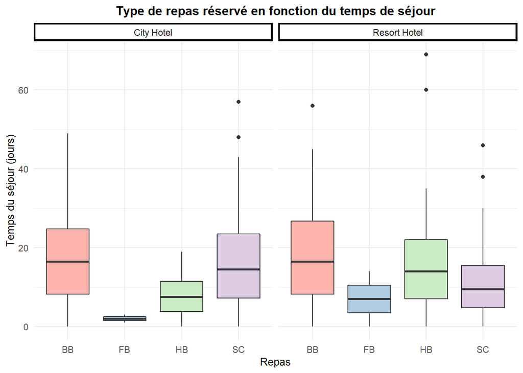

```r
hotels %>%
  select(meal, stays_in_weekend_nights, stays_in_week_nights, hotel) %>%
  filter(meal != "Undefined") %>%
  group_by(meal) %>%
  mutate(temps = stays_in_weekend_nights + stays_in_week_nights) %>%
  group_by(meal, temps, hotel) %>%
  summarise(N = n()) %>%
  ggplot(aes(x = meal, y = temps, fill = meal)) +
  geom_boxplot(show.legend = FALSE) +
  facet_wrap(~hotel) +
  scale_fill_brewer(palette = "Pastel1") +
  labs(x = "Repas", y = "Temps du séjour (jours)", title = "Type de repas réservé en fonction du temps de séjour" ) +
  theme_minimal() +
  theme(legend.title = element_blank(), plot.title = element_text(size = 12, face = "bold", hjust = 0.5  ),
        strip.background = element_rect(colour = "black", fill = "white", size = 1.5, linetype = "solid"),
        axis.title.x = element_text(size = 10),
        axis.title.y = element_text(size = 10))
```

Les clients ayant des séjours de courte durée, que ce soit dans le City Hotel ou le Resort Hotel, choisissent principalement la pension complète. Dans les City Hotel, les clients ayant des séjours de longue durée choisissent soit la formule “bed & breakfast” soit aucune formule en dehors du couchage. Inversement, dans les Resort Hotel, les clients choisissent la formule “bed & breakfast” mais également la formule “Half board” c’est à dire le petit déjeuner + un autre repas.

##### **10. Quels sont les types de chambre les plus réservés ? Par qui ?**

[figure not shown]

```r
hotels %>%
  mutate(famille = hotels$adults + hotels$children + hotels$babies) %>%
  filter(famille >= 1) %>%
  select(reserved_room_type, famille) %>%
  group_by(reserved_room_type, famille) %>%
  summarise(N = n()) %>%
  arrange(reserved_room_type) %>%
  drop_na() %>%
  top_n(2) %>%
  ggplot(aes(x = reserved_room_type, y = N, fill = famille)) +
  geom_col(colour = "black") +
  labs(x = "Types de chambre", y = "Nombre de réservation (en millier)", title = "Nombre de réservations par type d'hôtel en fonction des mois" ) +
  theme_minimal() +
  theme(legend.title = element_blank(), plot.title = element_text(size = 12, face = "bold", hjust = 0.5),
        strip.background = element_rect(colour = "black", fill = "white", size = 1.5, linetype = "solid"),
        axis.title.x = element_text(size = 10),
        axis.title.y = element_text(size = 10))
```

##### **11. Le temps de séjour a-t-il un impact sur le tarif journalier moyen ?**

```r
regression <- hotels %>%
  select(adr, stays_in_weekend_nights, stays_in_week_nights, hotel) %>%
  mutate(temps = stays_in_weekend_nights + stays_in_week_nights) %>%
  lm(adr ~ temps, data = .)

df <- tidy(regression)

df %>%
   kbl(col.names = c('Terme', 'Coefficients', 'Ecart-type', 'Statistique de test', 'p.value')) %>%
   kable_styling(bootstrap_options = c("hover", "condensed"))
```

| Terme | Coefficients | Ecart-type | Statistique de test | p.value |
| --- | --- | --- | --- | --- |
| (Intercept) | 97.228771 | 0.2440207 | 398.44475 | 0 |
| temps | 1.342615 | 0.0570570 | 23.53113 | 0 |

La régression linéaire nous informe que lorsque le temps de séjour augmente de 1 unité (1 jour), le prix du tarif journalier moyen augmente de 1.34. Le coefficient est significatif. En effet, la p.value étant égale ou inférieur à 0, elle est inférieure au seuil de significativité. Cependant, le tarif journalier moyen n’est pas stable. Le nombre de places de parking, le nombre de jours écoulés entre la réservation et le séjour ainsi que le type de chambre sont des facteurs qui pourraient faire varier le tarif journalier moyen.

> Conclusion

# Section par Paolo Crosetto

## Questions additionnelles

### 1. Questions variées

Une question-container qui contient plusieurs petites questions. 1. Pourquoi importez vous le package `{feasts}`? il sert à quoi? 2. Quelle est la fonction de `with()` et comment auriez-vous pu faire différemment en utilisant les outils du cours? 3. Pourquoi les parts de réservations ne somment pas à 100 dans la Q7? Essayez de corriger ce problème, s’il en est un.

```r
# 1. Le package "feasts" :

# J'ai téléchargé le package "feasts" pour utiliser la fonction "tidy".
# Grâce à "tidy", les données auront une meilleure mise en forme. De plus, "tidy" permet également d'avoir plus d'informations (comme par exemple dans ma question 11 avec la régression linéaire).

# 2. Fonction de "with" :

# L'utilsation de "with" était une alternative au "mutate" car je ne voulais pas créer de nouvelle variable. (ce que produit "mutate").
# J'ai modifié ma corrélation à la question 6. Ma ligne de code est plus simple et donne un bon résultat.

# 3. Correction du problème de la somme à 100% :

# Le problème a été corrigé !
```

### 2. Meilleure estimation Q11

C’es tune bonne question mais la méthode suivie n’est pas optimale. Pourquoi se limiter à 5% des observations? Pourquoi ne pas faire un modèle d’estimation (par ex régression linéaire) et en afficher les résultats? Il n’est pas si clair de votre plot que la rélation est en effet négative. Essayez de trouver une autre solution pour bien répondre à votre question; cela n’a pas nécessairement à être un plot mais il faut que le message qui sorte des données soit répresentatif (5% ne fait pas l’affaire) et clair.

```r
# Nouvelle question 11 sous forme de regression linéaire.
# cependant, le résultat ne nous permet pas de faire une conclusion. Plusieurs facteurs pourraient faire varier le résultat. Il aurait donc fallu faire des statistiques plus approfondies concernant les facteurs possibles.
```

### 3. Q5 tendances saisonnières

Formulez une nouvelle réponse à la Q5 (mois plus réservés) en écrasant l’info sur les années et en considerant juste les mois; cela vous permettra de vous concentrer sur la nature saisonnière ou pas des réservations. Essayez de bien montrer s’il y a des pics saisonniers ou pas (vous avez assez de finesse sur les dates dans les données) et montrez-le avec un plot plus convaincant / clair de celui qui a été proposé dans la première version.

```r
# J'ai utilisé la fonction "month.name" pour afficher les mois en entier. Sinon, j'aurais pu utiliser "month.abb" pour afficher seulement les 3 premières lettres.
```